# Building a Regional Grid

Author

Daniel van Denderen & Jan-Geert Hiddink

## Introduction

This step demonstrates how to create a spatial grid over a region of interest, assign an unqiue ID to the grid, and enrich the grid with environmental data such as depth and seabed stress.

We will predominantly use the R-packages sf and ggplot2 to build and visualize the dataset. The spatial grid is created for the Southern North Sea, corresponding to the data used in Step 2.

## Install and Load Required Libraries

We first load all the libraries and custom functions required for this analysis.

```r
# Load necessary libraries and custom functions
source("Libraries_needed.R")
source("Functions.R")
```

## Define the Grid Extent

We define the origin (lower-left corner), cell size, and number of cells to cover the area of interest.

```r
# Assign area of interest
origin   <- c(-2, 50)       # lower-left corner (long, lat)
cellsize <- c(0.05, 0.05)   # cell size in degrees
n_cells  <- c(200, 150)     # number of cells in x (long) and y (lat)

# Compute sequences of cell centers
x_coords <- origin[1] + (0:(n_cells[1]-1)) * cellsize[1] + cellsize[1]/2
y_coords <- origin[2] + (0:(n_cells[2]-1)) * cellsize[2] + cellsize[2]/2

# Create grid of cell centers
grid_centers <- expand.grid(x = x_coords, y = y_coords)
```

## Build the Grid as Polygons

Each grid cell is created as a polygon using its midpoint and the cell size.

```r
# Function to create a square polygon
make_cell <- function(x, y, dx, dy) {
  st_polygon(list(matrix(c(
    x - dx/2, y - dy/2,
    x + dx/2, y - dy/2,
    x + dx/2, y + dy/2,
    x - dx/2, y + dy/2,
    x - dx/2, y - dy/2
  ), ncol = 2, byrow = TRUE)))
}

# Create polygons
polygons_list <- mapply(make_cell, grid_centers$x, grid_centers$y,
                        MoreArgs = list(dx = cellsize[1],
                                        dy = cellsize[2]),
                        SIMPLIFY = FALSE)

# Convert to sf object
grid_sf <- st_sf(
  mid_long = grid_centers$x,
  mid_lat  = grid_centers$y,
  geometry = st_sfc(polygons_list),
  crs = 4326
)

grid_sf
```

```
Simple feature collection with 30000 features and 2 fields
Geometry type: POLYGON
Dimension:     XY
Bounding box:  xmin: -2 ymin: 50 xmax: 8 ymax: 57.5
Geodetic CRS:  WGS 84
First 10 features:
   mid_long mid_lat                       geometry
1    -1.975  50.025 POLYGON ((-2 50, -1.95 50, ...
2    -1.925  50.025 POLYGON ((-1.95 50, -1.9 50...
3    -1.875  50.025 POLYGON ((-1.9 50, -1.85 50...
4    -1.825  50.025 POLYGON ((-1.85 50, -1.8 50...
5    -1.775  50.025 POLYGON ((-1.8 50, -1.75 50...
6    -1.725  50.025 POLYGON ((-1.75 50, -1.7 50...
7    -1.675  50.025 POLYGON ((-1.7 50, -1.65 50...
8    -1.625  50.025 POLYGON ((-1.65 50, -1.6 50...
9    -1.575  50.025 POLYGON ((-1.6 50, -1.55 50...
10   -1.525  50.025 POLYGON ((-1.55 50, -1.5 50...
```

## Assign an unique id

C-squares are a spatial indexing system. We assign them to the grid cells.

```r
# Assign c-squares to each grid cell
grid_sf$csquares <- CSquare(grid_sf$mid_long, grid_sf$mid_lat, 0.05)
```

## Load Environmental Data

We now load environmental data (depth and habitat type) and match it to the grid based on the 0.05 c-square ID.

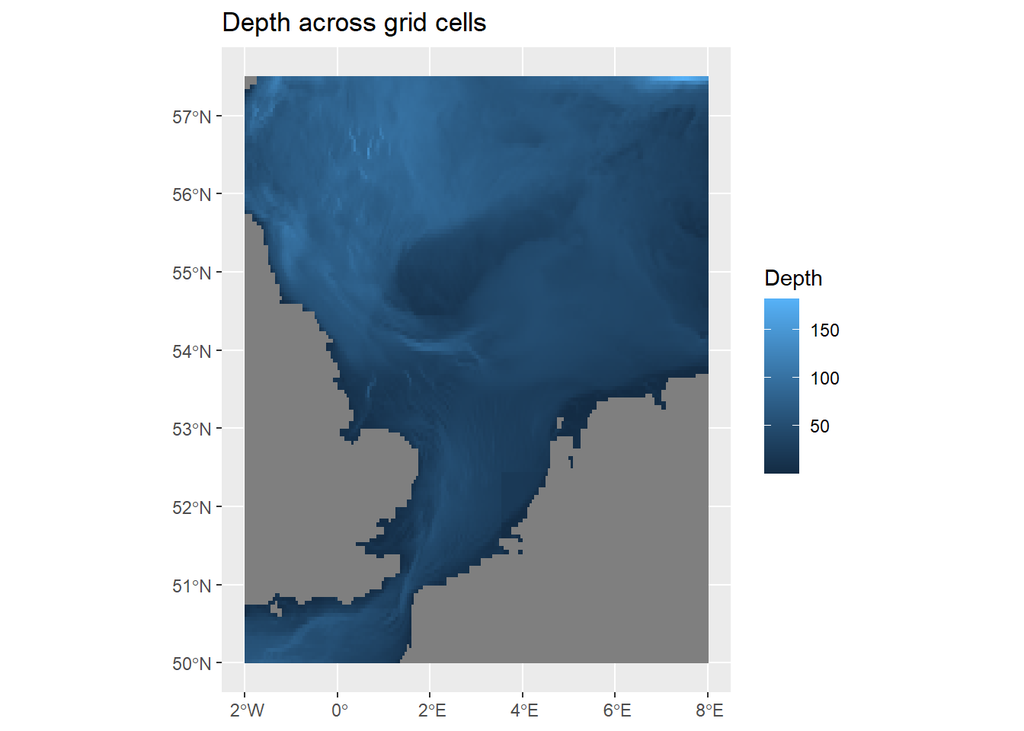

```r
# Load dataset
dat <- read.csv("data/250328_MSFDhabitat_depth.csv")

# Merge data with grid
grid_sf <- cbind(
  grid_sf,
  dat[match(grid_sf$csquares, dat$csquares),
      c("Ecoregion", "EEZ", "area_sqkm", "Depth", "Dominant_MSFD")]
)

# Quick visualization: depth
ggplot() +
  geom_sf(data = grid_sf, aes(col = Depth, fill=Depth)) +
  ggtitle("Depth across grid cells")
```

## Adding Other Environmental Data

Environmental data you add to the grid may differ in file type, grid resolution, and spatial or temporal coverage. Integrating these datasets into the grid often requires some adjustment. As an example, we will add seabed stress to the grid cell using the nearest mid-point.

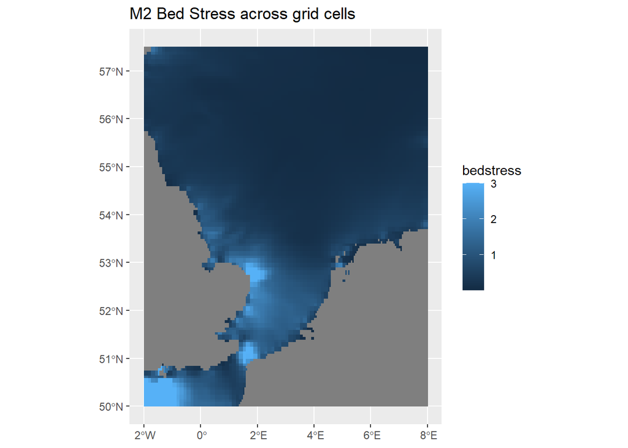

```r
# Load bed stress data
bstress <- read.csv("data/Shear stress/M2 bed stress.csv")

# Convert to sf
bstress_sf <- st_as_sf(bstress, coords = c("Longitude", "Latitude"), crs = 4326)
bstress_sf <- subset(bstress_sf, bstress_sf$M2.bedstress < 1e5)

# Find nearest grid midpoint
nearest_idx <- st_nearest_feature(grid_sf, bstress_sf)

# Assign bed stress
grid_sf$bedstress <- bstress_sf$M2.bedstress[nearest_idx]
grid_sf$bedstress[is.na(grid_sf$Dominant_MSFD)] <- NA

# Visualization: bed stress
ggplot() +
  geom_sf(data = grid_sf, aes(col = bedstress, fill=bedstress)) +
  ggtitle("M2 Bed Stress across grid cells")
```

## Save the Grid

Finally, we save the grid object for later use.

```r
# Save the result
save(grid_sf, file = "model/Region_grid.RData")

grid_sf
```

```
Simple feature collection with 30000 features and 9 fields
Geometry type: POLYGON
Dimension:     XY
Bounding box:  xmin: -2 ymin: 50 xmax: 8 ymax: 57.5
Geodetic CRS:  WGS 84
First 10 features:
   mid_long mid_lat       csquares         Ecoregion    EEZ area_sqkm    Depth
1    -1.975  50.025 7500:101:209:2 Greater North Sea France  19.92637 63.11740
2    -1.925  50.025 7500:101:209:1 Greater North Sea France  19.92637 65.40370
3    -1.875  50.025 7500:101:208:2 Greater North Sea France  19.92637 68.20849
4    -1.825  50.025 7500:101:208:1 Greater North Sea France  19.92637 71.38181
5    -1.775  50.025 7500:101:207:2 Greater North Sea France  19.92637 71.34726
6    -1.725  50.025 7500:101:207:1 Greater North Sea France  19.92637 72.49453
7    -1.675  50.025 7500:101:206:2 Greater North Sea France  19.92637 75.33410
8    -1.625  50.025 7500:101:206:1 Greater North Sea France  19.92637 76.92936
```

[output cut: 24 more lines]

## Done?

Obtain an environmental data layer for the southern North Sea from an online source, and then add this layer to your grid dataset.